# Simulation of the Central Limit Theorem and Basic Inferential Data Analysis

Author: Bo Liu

## Overview

This report consists of two parts, simulation of the Central Limit Theorem and Basic Inferential Data Analysis. In the first part, we will investigate the exponential distribution in R and compare it with the Central Limit Theorem. In the second part, we will do some basic inferential data analysis using the ToothGrowth data in the R datasets package.

## Simulation of the Central Limit Theorem

### SIMULATIONS

Set some parameters before we start the simulations. average_number stands for the number of exponentials. sample_number is the simulations times.

```r
lambda = 0.2
average_number = 40
sample_number = 1000
```

Sample the distribution of averages of 40 exponentials a thousand times.

```r
sample_mean_distribution<-sapply(1:sample_number,
                                 function(i)mean(rexp(average_number,lambda)))
head(sample_mean_distribution)
```

```
## [1] 3.712812 4.366301 5.697679 5.402912 6.989407 3.451457
```

### Sample Mean versus Theoretical Mean

Get the sample mean

```r
sample_mean <- mean(sample_mean_distribution)
sample_mean
```

```
## [1] 5.044702
```

Get the theoretical mean of the distribution which is 1/lambda.

```r
theoretical_mean <- 1/lambda
theoretical_mean
```

```
## [1] 5
```

Comparison of sample mean and theoretical mean

```r
sample_mean-theoretical_mean
```

```
## [1] 0.04470233
```

Plot the distribution of average 40 exponentials with sample mean and theoretical mean, the blue line indicates the sample mean and red line stands for the theoretical mean.

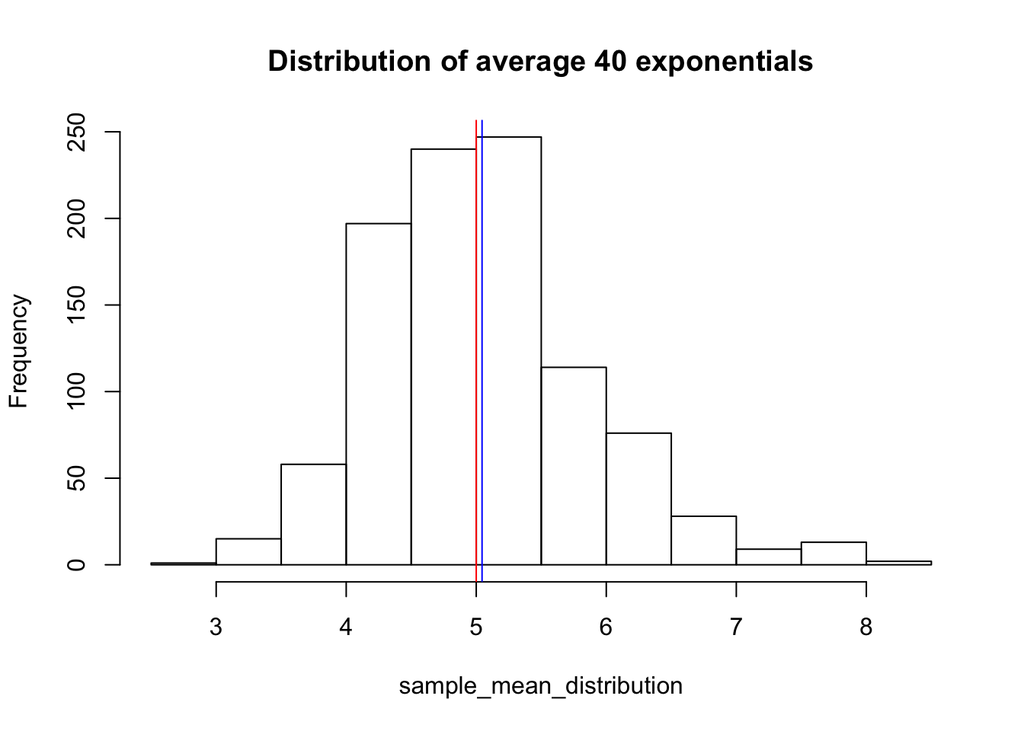

```r
hist(sample_mean_distribution,
     main="Distribution of average 40 exponentials",)
abline(v= sample_mean, col = "blue", lwd = 1)
abline(v= theoretical_mean, col = "red", lwd = 1)
```

It is pretty close, so CLT worked in this experiment.

### Sample Variance versus Theoretical Variance

First, get sample variance.

```r
sample_variance<-var(sample_mean_distribution)
sample_variance
```

```
## [1] 0.6888917
```

```r
theoretical_variance<-((1/lambda)^2)^2/sample_number
theoretical_variance
```

```
## [1] 0.625
```

Compare sample variance and theoretical variance

```r
sample_variance-theoretical_variance
```

```
## [1] 0.06389171
```

Plot the distribution of average 40 exponentials with sample variance and theoretical variance frome the sample mean, the blue line indicates the sample variance and red line stands for the theoretical variance.

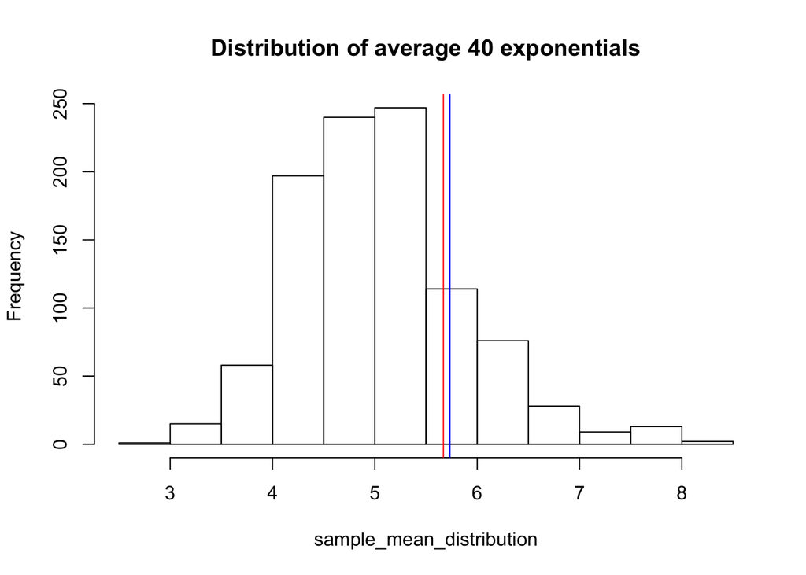

```r
hist(sample_mean_distribution,
     main="Distribution of average 40 exponentials")
abline(v= sample_mean+sample_variance, col = "blue", lwd = 1)
abline(v= sample_mean+theoretical_variance, col = "red", lwd = 1)
```

Those two lines are pretty close, so CLT worked again.

### Distribution

Plot the distribution of a large collection of random exponentials.

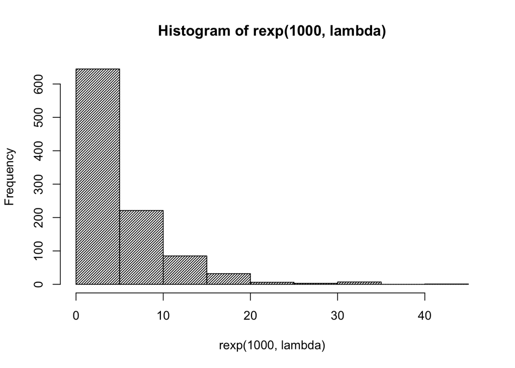

```r
hist(rexp(1000,lambda), density = 40)
```

Plot the distribution of a large collection of averages of 40 exponentials

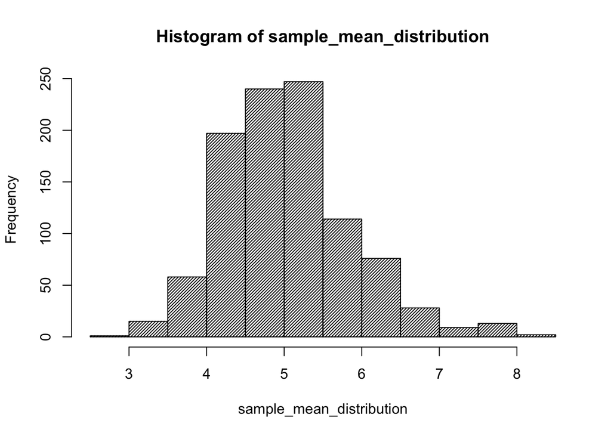

```r
hist(sample_mean_distribution, density = 40)
```

## Basic Inferential Data Analysis